# Exercise_7.3

Viktória Mészáros

## Data

I selected Milan as the city of my analysis. I checked how many observations are in most cities, and I saw that Milan has a bit more compared to Vienna so I felt it will be good for my analysis. I also filtered my data to hotels that has 3 to 4 stars for a November 2017 weekday. This cleaned and filtered data was saved to my [Github](https://github.com/Viki-Meszaros/CEU-Data_analysis_2/blob/main/Extra_tasks/Data/Milan_hotels.csv) repo and it is imported from there in this markdown. You can see the cleaning in the Clean_hotels_data.R file and the filtering in the [Exercise_7_3.R] file.

## Distribution of distance and price

First I created a histogram to have a look on the distribution of distances. There are some extreme values but they are not far from the other observations, so I decided not to exclude any observations here.

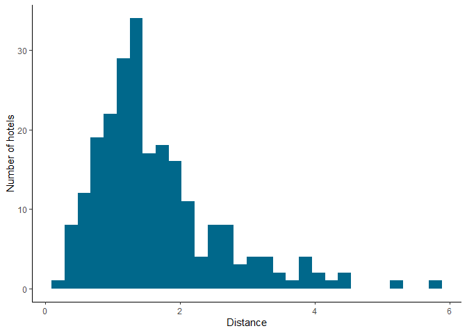

For price I also looked at the histogram. Here we can see that almost all of the hotels are having a price below 400 USD, but there is one observation with a price above 800 USD. As the aim of my analysis was to find a good deal and it is straight forward this hotel is not that I decided to exclude it from my data. I seems to be an influential observation and as it does not support my aim, it is better to get rid of it.

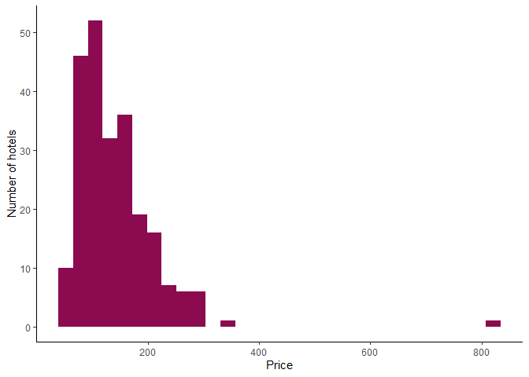

## Bin scatter

This bin scatter shows a non-parametric regression with 4 bins. This first graph shows only four dots for the four bins.

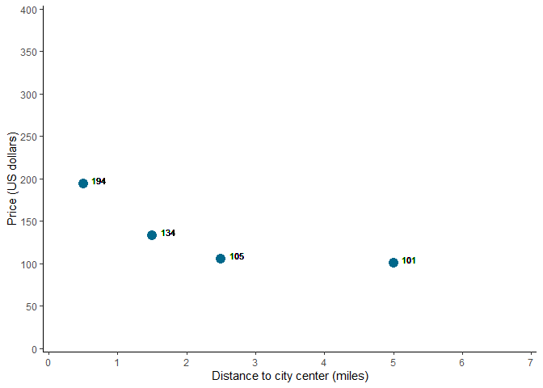

This graph if more informative as we can see how the value of the bins fit to the scatterplot of the distribution. From both of the graphs we can conclude that there is a negative pattern of association between distance from the city center and price of the hotels.

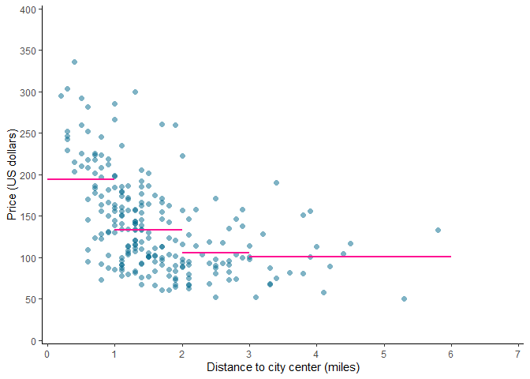

## Lowess regression

From the lowess regression it becomes even more clear that there is truly a negative pattern between the two variables. It also becomes visible that this pattern is not linear.

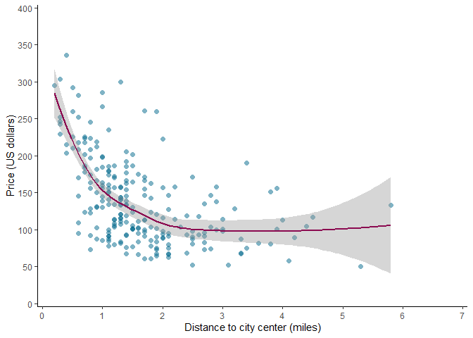

## Linear regression

```
##
## Call:
## lm(formula = price ~ distance, data = hotels)
##
## Residuals:
##     Min      1Q  Median      3Q     Max
## -90.412 -37.432  -7.427  31.065 160.600
##
## Coefficients:
##             Estimate Std. Error t value Pr(>|t|)
## (Intercept)  187.388      6.638  28.228  < 2e-16 ***
## distance     -29.970      3.513  -8.532 1.99e-15 ***
## ---
## Signif. codes:  0 '***' 0.001 '**' 0.01 '*' 0.05 '.' 0.1 ' ' 1
##
## Residual standard error: 50.23 on 229 degrees of freedom
## Multiple R-squared:  0.2412, Adjusted R-squared:  0.2379
## F-statistic: 72.79 on 1 and 229 DF,  p-value: 1.99e-15
```

The regression coefficients show that when the hotel is in the city center (distance is 0) the expected price you are going to pay is 187.4 USD. When you go 1 miles further from the center the average hotel price is expected to be 30 USDs lower. This model covers 24.12% of the variation of the price which is fine, but we can clearly see that with adjusting the model for non-linearity we would get much better fit.

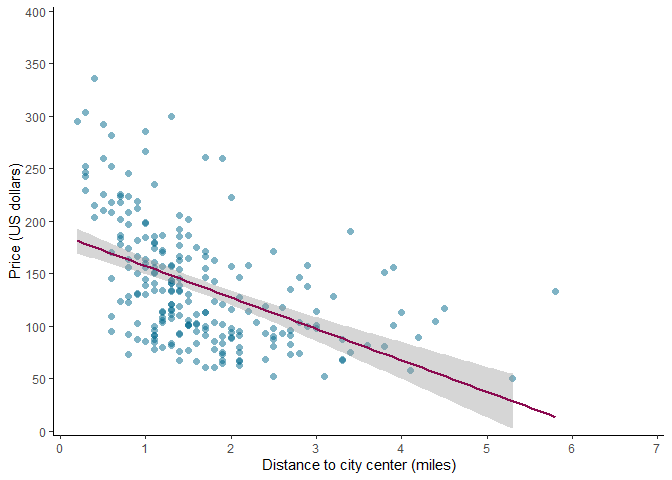